# Quantitative evidence synthesis for biodiversity

Shane Blowes

Shanghai 2024

The use of quantitative evidence synthesis has accelerated exponentially since approximately the mid-1990s (Gurevitch et al. 2018).

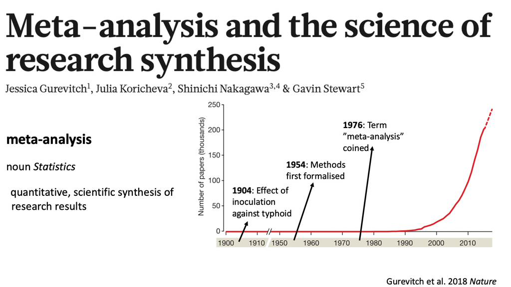

This broad trend for quantitative evidence synthesis, and meta-analysis in particular, is also true for ecologists and conservation biologists (Anderson et al. 2021).

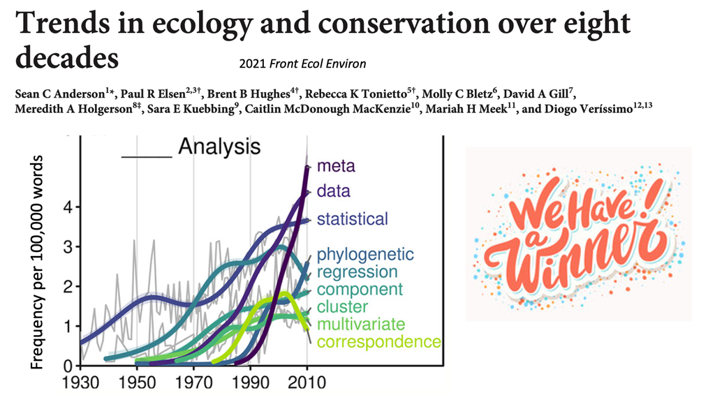

For biodiversity synthesis, two obstacles soon become apparent when we start diving into the literature search for a meta-analysis.

First, the tyranny of the many indices will quickly become apparent: no matter which effect size you target (e.g., log-ratio, Hedge’s G, etc), the many different biodiversity measures (e.g., species richness, total abundance, Shannon diversity, Simpson diversity, one of the Hill numbers, etc.) will limit the number of studies you can collate. Second, the two things that we emphasise as being important for describing variation in biodiversity - scale and the multiple components of abundance, evenness and richness - will be inaccessible for most meta-analyses. Multi-scale analyses are predominantly out of reach because most studies will have only quantified biodiversity at a single scale. Similarly, multi-component analyses will be constrained by the fact that most studies will have used one or two metrics, and the scope for coherently combining these metrics across studies will be limited.

Even for a single metric such as species richness, a within system meta-analysis will risk comparing apples to oranges because different studies will likely have used different sample grains to sample the target assemblage. Let’s do a simple simulation to examine the implication of variation in grain size for our ability to generalise an effect size.

### How does variation in sample grain confound average effect sizes?

To examine how variation in grain size influences a meta-analysis, we will use simulations. Let’s start by simulating an experiment that removes half of the species in a community.

```r
library(tidyverse)
library(mobsim)
library(mobr)
library(cowplot)

# set a RNG seed
set.seed(42)

# Set all communities to have 5000 individuals,
# a lognormal SAD, and individuals randomly distributed in space
Jpool <- 2000

# We want to treatment to half the number of species
Spool_control <- 200
# treatment removes 50% of the species
Spool_treatment <- 0.5 * Spool_control

# simulate a meta-analysis with twenty studies
n_study <- 20

meta_sim <- tibble(
  Jpool = Jpool,
  S_control = Spool_control,
  S_treatment = Spool_treatment) %>%
  # create the n_studies
  uncount(n_study, .remove = FALSE) %>%
  # here, we are interested in examining variation in sample grain.
  # Draw some random quadrat sizes from a uniform distribution
  mutate(sample_grain = runif(n_study,
                              min = 0.01,
                              max = 0.1)) %>%
  # create index to identify each study
  mutate(study = as.character(1:n_study)) %>%
  # prepare to generate control and treatment communities for each study
  group_by(study) %>%
  nest(data = c(Jpool, S_control, S_treatment,
                sample_grain)) %>%
  # simulate poisson distribution of individuals for the controls and
  # treatments within each study
  mutate(control_comm = map(data,
                            ~sim_poisson_community(
                              s_pool = .x$S_control,
                              n_sim = .x$Jpool,
                              sad_type = 'lnorm',
                              sad_coef = list('meanlog' = log(.x$S_control/.x$Jpool),
                                              'sdlog' = 1))),
         treatment_comm = map(data,
                              ~sim_poisson_community(
                                s_pool = .x$S_treatment,
                                n_sim = .x$Jpool,
                                sad_type = 'lnorm',
                                sad_coef = list('meanlog' = log(.x$S_treatment/.x$Jpool),
                                                'sdlog' = 1)
                                )
                              )
         ) %>%
  # to check our treatment worked calculate abundance and richness for the
  # whole community (which is the scale at which we applied the treatment)
  mutate(control_comm_J = map(control_comm, ~nrow(.x$census)),
         control_comm_S = map(control_comm, ~n_distinct(.x$census$species)),
         treatment_comm_J = map(treatment_comm, ~nrow(.x$census)),
         treatment_comm_S = map(treatment_comm, ~n_distinct(.x$census$species))) %>%
  # now, we want to get some samples from the controls and treatments
  # we'll just keep the site x species matrix
  mutate(control_samps = map2(control_comm, data,
                             ~ sample_quadrats(comm = .x,
                                               # we'll take 5 samples
                                               n_quadrats = 5,
                                               # with the sample_grain for this study
                                               quadrat_area = .y$sample_grain,
                                               method = 'grid',
                                               plot = FALSE)$spec_dat),
         treatment_samps = map2(treatment_comm, data,
                             ~ sample_quadrats(comm = .x,
                                               # we'll take 5 samples
                                               n_quadrats = 5,
                                               # with the sample_grain for this study
                                               quadrat_area = .y$sample_grain,
                                               method = 'grid',
                                               plot = FALSE)$spec_dat)) %>%
  # let's calculate metrics for abundance, richness, and the ENS conversion
  # of PIE (for inferences about evenness)
  # note, because we're simulating what we'd typically find when doing a meta-analysis,
  # we're only going to do the calculations at a single scale
  mutate(control_J = map(control_samps, ~ rowSums(.x)),
         control_S = map(control_samps, ~ vegan::specnumber(.x, MARGIN = 1)),
         control_SPIE = map(control_samps, ~ mobr::calc_comm_div(.x, index = 'S_PIE',
                                                                extrapolate = FALSE,
                                                                scales = 'alpha')$value),
         treatment_J = map(treatment_samps, ~ rowSums(.x)),
         treatment_S = map(treatment_samps, ~ vegan::specnumber(.x, MARGIN = 1)),
         treatment_SPIE = map(treatment_samps, ~ mobr::calc_comm_div(.x, index = 'S_PIE',
                                                                extrapolate = FALSE,
                                                                scales = 'alpha')$value)) %>%
  ungroup()

# calculate log-ratio effect sizes
effect_sizes <- meta_sim %>%
  unnest(c(data, control_J, control_S, control_SPIE,
           treatment_J, treatment_S, treatment_SPIE)) %>%
  mutate(J_LRR = log(treatment_J/control_J),
         S_LRR = log(treatment_S/control_S),
         SPIE_LRR = log(treatment_SPIE/control_SPIE))
```

We’re not focused on the details of meta-analysis today, so we won’t fit any statistical models. Instead, we’ll look at the data and calculate some averages.

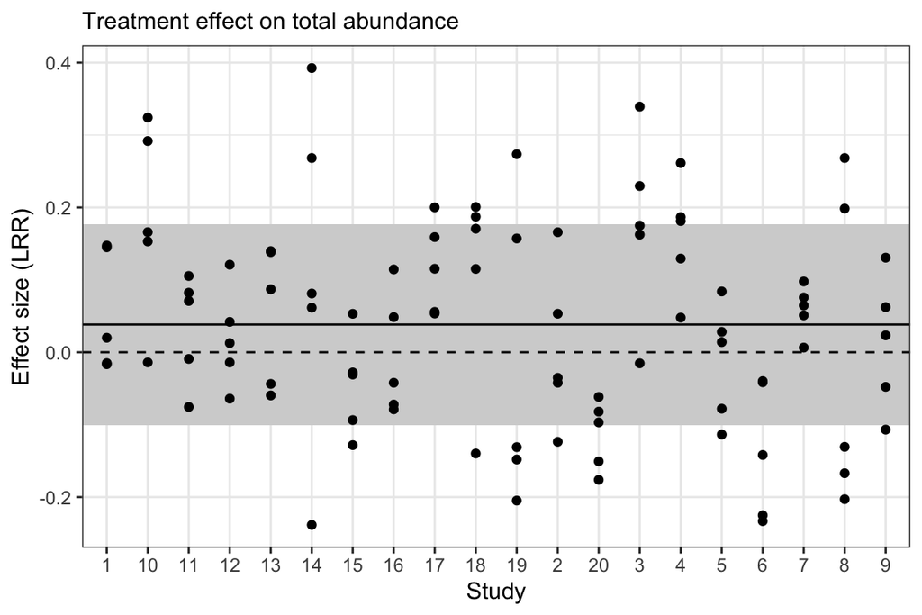

```r
# plot come effect sizes, let's start with total numbers of individuals
effect_sizes %>%
  # calculate the mean and sd
  mutate(J_LRR_mean = mean(J_LRR),
         J_LRR_sd = sd(J_LRR)) %>%
  ggplot() +
  geom_rect(aes(xmin = -Inf, xmax = Inf,
                  ymin = J_LRR_mean - J_LRR_sd,
                  ymax = J_LRR_mean + J_LRR_sd),
                fill = 'light grey') +
  geom_hline(aes(yintercept = J_LRR_mean)) +
  # and plot the known effect size on total abundance
  geom_hline(yintercept = 0, lty = 2) +
  geom_point(aes(x = study, y = J_LRR)) +
  labs(x = 'Study',
       y = 'Effect size (LRR)',
       subtitle = 'Treatment effect on total abundance') +
  theme_bw()
```

Nice. We have got the no effect on total abundance approximately right.

What about species richness?

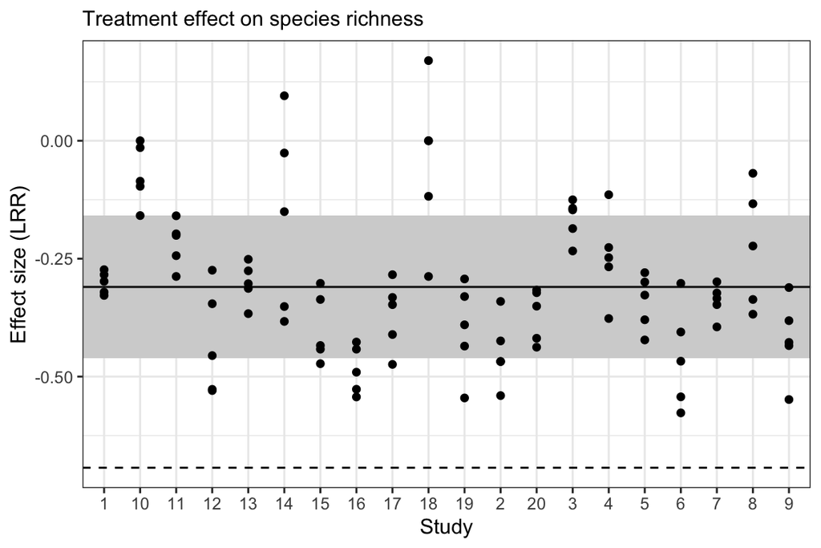

```r
# now species richness, note our known effect size
S_LRR_known <- log(0.5)

effect_sizes %>%
  # calculate the mean and sd
  mutate(S_LRR_mean = mean(S_LRR),
         S_LRR_sd = sd(S_LRR)) %>%
  ggplot() +
  geom_rect(aes(xmin = -Inf, xmax = Inf,
                  ymin = S_LRR_mean - S_LRR_sd,
                  ymax = S_LRR_mean + S_LRR_sd),
                fill = 'light grey') +
  geom_hline(aes(yintercept = S_LRR_mean)) +
  # let's plot the known effect size as a dashed line
  geom_hline(yintercept = S_LRR_known, linetype = 2) +
  geom_point(aes(x = study, y = S_LRR)) +
  labs(x = 'Study',
       y = 'Effect size (LRR)',
       subtitle = 'Treatment effect on species richness') +
  theme_bw()
```

Here, it looks like we have underestimated the effect. The magnitude of our error would depend on the distribution of grain sizes, and the scale at which the effect impacted biodiversity, both of which would likely vary among studies. Here we know that the effect was applied at a grain size of one, while our grain sizes between 0.01 and 0.1. In an empirical synthesis of  
observational data, we would not know the true effect (nor the scale at which it would impact the community).

An important recommendation for all biodiversity syntheses, and in particular, for meta-analyses with a diversity measure as the response variable is to plot effect sizes as a function of scale (e.g., sample grain and extent) (Spake et al. 2021).

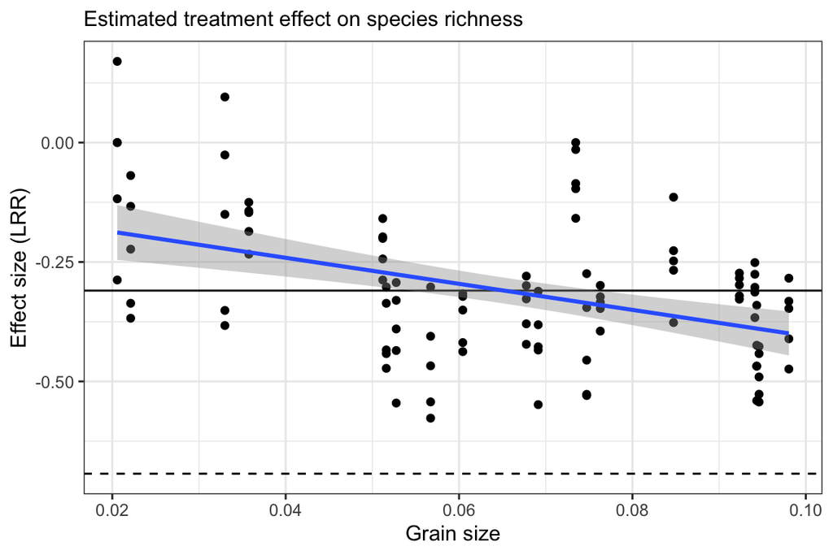

```r
effect_sizes %>%
  # calculate the mean and sd of the sample ESs
  mutate(S_LRR_mean = mean(S_LRR),
         S_LRR_sd = sd(S_LRR)) %>%
  ggplot() +
  geom_hline(aes(yintercept = S_LRR_mean)) +
  # plot the known effect size as a dashed line
  geom_hline(yintercept = S_LRR_known, linetype = 2) +
  # plot the sample effect sizes
  geom_point(aes(x = sample_grain, y = S_LRR)) +
  # to see if we've got any evidence for scale-dependence
  # we'll visualise a linear model with the effect sizes as a function of
  # grain size
  stat_smooth(aes(x = sample_grain, y = S_LRR),
              method = 'lm') +
  labs(x = 'Grain size',
       y = 'Effect size (LRR)',
       subtitle = 'Estimated treatment effect on species richness') +
  theme_bw()
```

Some grain-size dependence in the average effect size for species richness. And larger grains are closer to the known ES.

Let’s repeat the exercise, but this time we’ll have the treatment effect the numbers of individuals. Before we start, what is your expectation? Do you think we’ll be able to accurately recover the known effect size for total numbers of individuals independently of the grain size variation? What about species richness?

```r
# this time both control and treatment have the same number of species
Spool <- 200

# Simulate different communities sizes for the control and treatment
Jpool_control <- 5000
# treatment removes 60% of the individuals
Jpool_treatment <- 2000


meta_sim2 <- tibble(
  Spool = Spool,
  J_control = Jpool_control,
  J_treatment = Jpool_treatment,
) %>%
  # create the n_studies
  uncount(n_study, .remove = FALSE) %>%
  # here, we are interested in examining how variation in sample grain.
  # So, we'll draw some random quadrat sizes from a uniform distribution
  mutate(sample_grain = runif(n_study,
                              min = 0.01,
                              max = 0.1)) %>%
  # create index to identify each study
  mutate(study = 1:n_study) %>%
  # prepare to generate control and treatment communities for each study
  group_by(study) %>%
  nest(data = c(Spool, J_control, J_treatment,
                sample_grain)) %>%
  # simulate poisson distribution of individuals for the controls and
  # treatments within each study
  mutate(control_comm = map(data, ~ sim_poisson_community(s_pool = .x$Spool,
                                          n_sim = .x$J_control,
                                          sad_type = 'lnorm',
                                          sad_coef = list('meanlog' = log(.x$Spool/.x$J_control),
                                                          'sdlog' = 1))),
         treatment_comm = map(data, ~ sim_poisson_community(s_pool = .x$Spool,
                                          n_sim = .x$J_treatment,
                                          sad_type = 'lnorm',
                                          sad_coef = list('meanlog' = log(.x$Spool/.x$J_treatment),
                                                          'sdlog' = 1)))) %>%
  # now, we want to get some samples from the controls and treatments
  # we'll just keep the site x species matrix
  mutate(control_samps = map2(control_comm, data,
                             ~ sample_quadrats(comm = .x,
                                               # we'll take 5 samples
                                               n_quadrats = 5,
                                               # with the sample_grain for this study
                                               quadrat_area = .y$sample_grain,
                                               method = 'grid',
                                               plot = FALSE)$spec_dat),
         treatment_samps = map2(treatment_comm, data,
                             ~ sample_quadrats(comm = .x,
                                               # we'll take 5 samples
                                               n_quadrats = 5,
                                               # with the sample_grain for this study
                                               quadrat_area = .y$sample_grain,
                                               method = 'grid',
                                               plot = FALSE)$spec_dat)) %>%
  # let's calculate metrics for abundance, richness, and the ENS conversion
  # of PIE (for inferences about evenness)
  # note, because we're simulating what we'd typically find when doing a meta-analysis,
  # we're only going to do the calculations at a single scale
  mutate(control_J = map(control_samps, ~ rowSums(.x)),
         control_S = map(control_samps, ~ vegan::specnumber(.x, MARGIN = 1)),
         control_SPIE = map(control_samps, ~ mobr::calc_comm_div(.x, index = 'S_PIE',
                                                                extrapolate = FALSE,
                                                                scales = 'alpha')$value),
         treatment_J = map(treatment_samps, ~ rowSums(.x)),
         treatment_S = map(treatment_samps, ~ vegan::specnumber(.x, MARGIN = 1)),
         treatment_SPIE = map(treatment_samps, ~ mobr::calc_comm_div(.x, index = 'S_PIE',
                                                                extrapolate = FALSE,
                                                                scales = 'alpha')$value)) %>%
  ungroup()

# calculate log-ratio effect sizes
effect_sizes2 <- meta_sim2 %>%
  unnest(c(data, control_J, control_S, control_SPIE,
           treatment_J, treatment_S, treatment_SPIE)) %>%
  mutate(J_LRR = log(treatment_J/control_J),
         S_LRR = log(treatment_S/control_S),
         SPIE_LRR = log(treatment_SPIE/control_SPIE))
```

Again, we’ll focus on visual inspection and the averages instead of fitting statistical models and a more formal analysis.

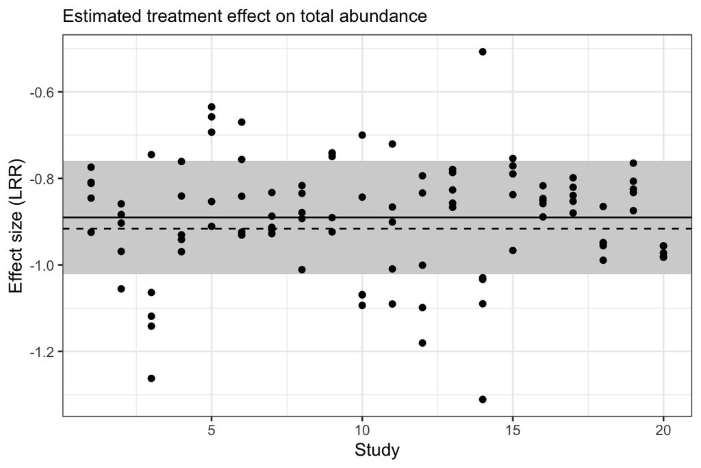

```r
# plot come effect sizes, let's start with total numbers of individuals
J_LRR_known = log(2/5)

effect_sizes2 %>%
  # calculate the mean and sd
  mutate(J_LRR_mean = mean(J_LRR),
         J_LRR_sd = sd(J_LRR)) %>%
  ggplot() +
  geom_rect(aes(xmin = -Inf, xmax = Inf,
                  ymin = J_LRR_mean - J_LRR_sd,
                  ymax = J_LRR_mean + J_LRR_sd),
                fill = 'light grey') +
  geom_hline(aes(yintercept = J_LRR_mean)) +
  # and plot the known effect size on total abundance
  geom_hline(yintercept = J_LRR_known, lty = 2) +
  geom_point(aes(x = study, y = J_LRR)) +
  labs(x = 'Study',
       y = 'Effect size (LRR)',
       subtitle = 'Estimated treatment effect on total abundance') +
  theme_bw()
```

We still estimate the known effect on total numbers of individuals well. Why?

What about species richness?

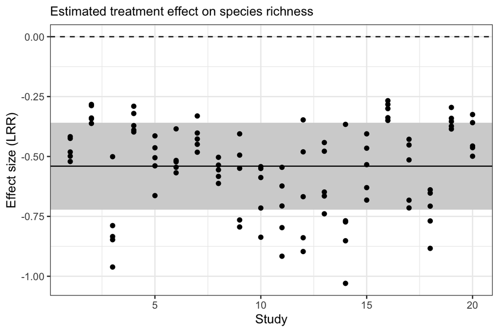

```r
# now species richness, note our known effect size
S_LRR_known <- 0

effect_sizes2 %>%
  # calculate the mean and sd
  mutate(S_LRR_mean = mean(S_LRR),
         S_LRR_sd = sd(S_LRR)) %>%
  ggplot() +
  geom_rect(aes(xmin = -Inf, xmax = Inf,
                  ymin = S_LRR_mean - S_LRR_sd,
                  ymax = S_LRR_mean + S_LRR_sd),
                fill = 'light grey') +
  geom_hline(aes(yintercept = S_LRR_mean)) +
  # let's plot the known effect size as a dashed line
  geom_hline(yintercept = S_LRR_known, linetype = 2) +
  geom_point(aes(x = study, y = S_LRR)) +
  labs(x = 'Study',
       y = 'Effect size (LRR)',
       subtitle = 'Estimated treatment effect on species richness') +
  theme_bw()
```

Now we’ve overestimated the effect on species richness! Again, the magnitude of our error would depend on the distribution of grain sizes, and the scale at which the effect impacted biodiversity (both of which would be unknown in an empirical meta-analysis, though here we know that there was no effect on community richness).

Let’s look at whether we have strong scale dependence in the effect sizes (Spake et al. 2021).

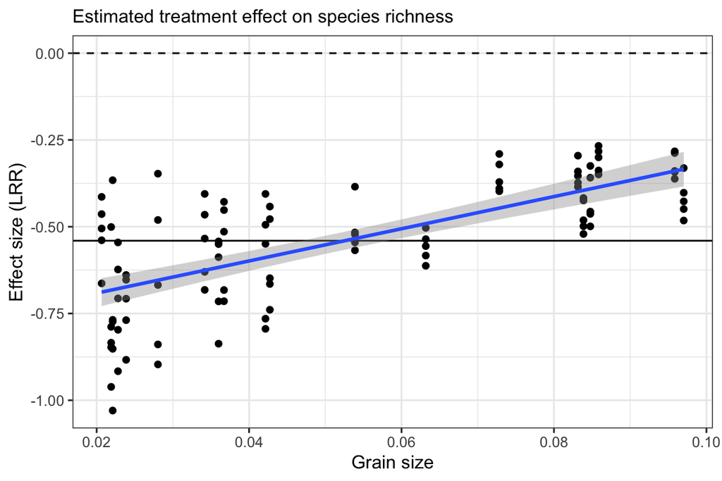

```r
effect_sizes2 %>%
  # calculate the mean and sd
  mutate(S_LRR_mean = mean(S_LRR),
         S_LRR_sd = sd(S_LRR)) %>%
  ggplot() +
  geom_hline(aes(yintercept = S_LRR_mean)) +
  # let's plot the known effect size as a dashed line
  geom_hline(yintercept = S_LRR_known, linetype = 2) +
  geom_point(aes(x = sample_grain, y = S_LRR)) +
  # let's see if we've got any evidence for scale-dependence
  # by fitting a linear model to the effect size as a function of
  # grain size
  stat_smooth(aes(x = sample_grain, y = S_LRR),
              method = 'lm') +
  labs(x = 'Grain size',
       y = 'Effect size (LRR)',
       subtitle = 'Estimated treatment effect on species richness') +
  theme_bw()
```

What happened to evenness? Is our estimated ES grain-size dependent?

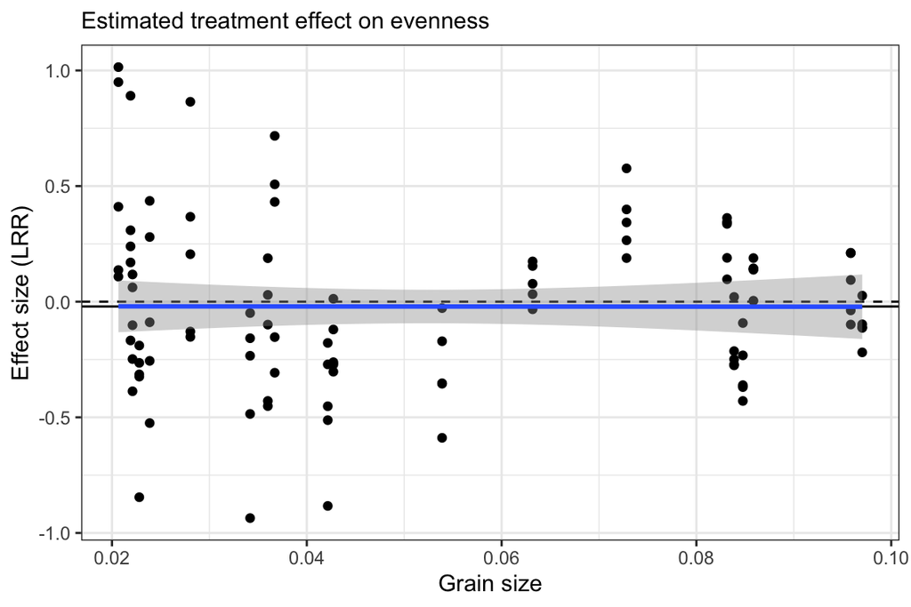

```r
effect_sizes2 %>%
  # calculate the mean and sd
  mutate(SPIE_LRR_mean = mean(SPIE_LRR),
         SPIE_LRR_sd = sd(SPIE_LRR)) %>%
  ggplot() +
  geom_hline(aes(yintercept = SPIE_LRR_mean)) +
  # let's plot the known effect size as a dashed line
  geom_hline(yintercept = 0, linetype = 2) +
  geom_point(aes(x = sample_grain, y = SPIE_LRR)) +
  # let's see if we've got any evidence for scale-dependence
  # by fitting a linear model to the effect size as a function of
  # grain size
  stat_smooth(aes(x = sample_grain, y = SPIE_LRR),
              method = 'lm') +
  labs(x = 'Grain size',
       y = 'Effect size (LRR)',
       subtitle = 'Estimated treatment effect on evenness') +
  theme_bw()
```

### Exercise

Our initial simulations had communities where individuals were distributed randomly in space. This helped simplify interpreting what we found, but is likely unrealistic for most communities (though it might be appropriate for some experimental conditions). Repeat the simulations, but this time add some within species aggregation.

### References

Anderson, Sean C, Paul R Elsen, Brent B Hughes, Rebecca K Tonietto, Molly C Bletz, David A Gill, Meredith A Holgerson, et al. 2021. “Trends in Ecology and Conservation over Eight Decades.” *Frontiers in Ecology and the Environment* 19 (5): 274–82.

Gurevitch, Jessica, Julia Koricheva, Shinichi Nakagawa, and Gavin Stewart. 2018. “Meta-Analysis and the Science of Research Synthesis.” *Nature* 555 (7695): 175–82.

Spake, Rebecca, Akira S. Mori, Michael Beckmann, Philip A. Martin, Alec P. Christie, Marlyse C. Duguid, and C. Patrick Doncaster. 2021. “Implications of Scale Dependence for Cross-Study Syntheses of Biodiversity Differences.” *Ecology Letters* 24 (2): 374–90.